# Efeito da Lei 13.811/2019 sobre Casamento Infantil

Inferência Causal: DR-DiD · HonestDiD · DiDC

21 de julho de 2026

## Contexto

A **Lei 13.811/2019** aboliu todas as exceções ao casamento infantil no Brasil.

- **Regra anterior:** casamento permitido a partir de **16 anos** com autorização judicial/parental.
- **Regra nova:** vedação **absoluta** para menores de 18 anos.

O limiar de 16 anos é a descontinuidade estrutural explorada nas estratégias de identificação.

### Sequência de análises

| Bloco | Método | Pergunta |
| --- | --- | --- |
| **1** | Event Study FEOLS — 15 vs 16 | Tendências paralelas sustentam o design? |
| **1b–1c** | DR-DiD + HonestDiD — 15 vs 16 | Estimativa + sensibilidade (design diagnóstico) |
| **2–3** | DR-DiD + HonestDiD — 14–15 vs 16–17 | Estimativa principal |
| **4–5** | DR-DiD + HonestDiD — 14–15 vs 17–18 | Robustez (controle alternativo) |
| **6** | DiDC rdrobust | **Estimador preferido** — sem hipótese de tendências paralelas |

## Bloco 0 — Parâmetros

```r
cat(sprintf("Ano de referência:   %d\n", ANO_REF))
```

```
## Ano de referência:   2018
```

```r
cat(sprintf("Anos pré:            %s\n", paste(ANOS_PRE, collapse=", ")))
```

```
## Anos pré:            2012, 2013, 2014, 2015, 2016, 2017
```

```r
cat(sprintf("Anos pós:            %s\n", paste(ANOS_POS, collapse=", ")))
```

```
## Anos pós:            2019, 2022, 2023, 2024, 2025
```

```r
cat(sprintf("Idades tratadas:     %s anos\n", paste(IDADES_TRAT, collapse="–")))
```

```
## Idades tratadas:     14–15 anos
```

```r
cat(sprintf("Controle principal:  %s anos\n", paste(IDADES_CTRL1, collapse="–")))
```

```
## Controle principal:  16–17 anos
```

```r
cat(sprintf("Controle alternativo:%s anos\n", paste(IDADES_CTRL2, collapse="–")))
```

```
## Controle alternativo:17–18 anos
```

```r
cat(sprintf("Covariáveis DR-DiD:  %s\n", deparse(COVAR_FORMULA)))
```

```
## Covariáveis DR-DiD:  ~parda_preta + rural + uf_fct
```

## Bloco 1 — Event Study 15 vs 16 (Diagnóstico)

Pergunta: o design mais restrito — idades 15 e 16, vizinhos imediatos do cutoff legal — sustenta tendências paralelas entre 2012 e 2018?

**Expectativa:** como 16 era o limiar legal antes de 2019, a diferença entre 15 e 16 anos já era estruturalmente diferente de zero *antes* da lei — não por falha de identificação, mas pela própria norma. Isso motiva o DiDC (Bloco 6).

### Código

```r
# LPM com efeitos fixos de UF e ano, SE clusterizados por UF
# i(Ano, D_15, ref=2018): cada coeficiente = gap tratada−controle naquele ano
mod_1516 <- feols(
  em_uniao ~ i(Ano, D_15, ref = ANO_REF) + parda_preta + rural |
    ano_fct + uf_fct,
  data = dados_1516, weights = ~pes_comcalib, cluster = ~uf_fct
)
# Teste Wald conjunto: H0: β_2012 = ... = β_2017 = 0
chi2_1516 <- sum((evt_pre_1516$estimate / evt_pre_1516$se)^2)
pval_1516 <- pchisq(chi2_1516, df=nrow(evt_pre_1516), lower.tail=FALSE)
```

### Coeficientes do event study

```r
coef_1516 |>
  filter(ano != ANO_REF) |>
  transmute(
    Ano      = ano,
    `β (pp)` = round(estimate * 100, 3),
    `SE (pp)`= round(se * 100, 3),
    `IC inf` = round(ci_lo * 100, 3),
    `IC sup` = round(ci_hi * 100, 3),
    `t-stat` = round(estimate / se, 2),
    `Período`= if_else(pre, "Pré", "Pós")
  ) |>
  knitr::kable(
    caption = "Event study FEOLS — 15 vs 16 anos. Referência: 2018 (β = 0). Valores em pp.",
    align   = "rrrrrrl"
  )
```

Event study FEOLS — 15 vs 16 anos. Referência: 2018 (β = 0). Valores em pp.

| Ano | β (pp) | SE (pp) | IC inf | IC sup | t-stat | Período |
| --- | --- | --- | --- | --- | --- | --- |
| 2012 | -1.547 | 0.444 | -2.417 | -0.677 | -3.49 | Pré |
| 2013 | -1.958 | 0.416 | -2.774 | -1.143 | -4.71 | Pré |
| 2014 | -2.073 | 0.354 | -2.766 | -1.380 | -5.86 | Pré |
| 2015 | -2.157 | 0.384 | -2.910 | -1.403 | -5.61 | Pré |
| 2016 | -2.190 | 0.477 | -3.125 | -1.256 | -4.60 | Pré |
| 2017 | -1.754 | 0.552 | -2.836 | -0.672 | -3.18 | Pré |
| 2019 | -1.697 | 0.548 | -2.770 | -0.624 | -3.10 | Pós |
| 2022 | -0.542 | 0.517 | -1.556 | 0.472 | -1.05 | Pós |
| 2023 | -1.092 | 0.366 | -1.810 | -0.374 | -2.98 | Pós |
| 2024 | -1.252 | 0.491 | -2.214 | -0.289 | -2.55 | Pós |
| 2025 | -0.879 | 0.312 | -1.491 | -0.267 | -2.82 | Pós |

### Teste Wald de tendências paralelas

```r
cat(sprintf("Wald pré-tendências (β_2012 = ... = β_2017 = 0):\n"))
```

```
## Wald pré-tendências (β_2012 = ... = β_2017 = 0):
```

```r
cat(sprintf("  χ²(%d) = %.2f\n", nrow(evt_pre_1516), chi2_1516))
```

```
##   χ²(6) = 131.36
```

```r
cat(sprintf("  p-valor = %.6f\n\n", pval_1516))
```

```
##   p-valor = 0.000000
```

```r
if (pval_1516 < 0.05) {
  cat("REJEIÇÃO ao nível de 5%.\n")
  cat("Tendências paralelas NÃO são sustentadas para o design 15 vs 16.\n\n")
  cat("Razão estrutural: o limiar de 16 anos era o limiar legal de casamento\n")
  cat("antes de 2019. A diferença pré-2019 entre 15 e 16 anos reflete a\n")
  cat("própria norma — não é corrigível por covariáveis.\n")
  cat("→ Motivação empírica para o DiDC (Bloco 6).\n")
}
```

```
## REJEIÇÃO ao nível de 5%.
## Tendências paralelas NÃO são sustentadas para o design 15 vs 16.
##
## Razão estrutural: o limiar de 16 anos era o limiar legal de casamento
## antes de 2019. A diferença pré-2019 entre 15 e 16 anos reflete a
## própria norma — não é corrigível por covariáveis.
## → Motivação empírica para o DiDC (Bloco 6).
```

### Figura — Tendências

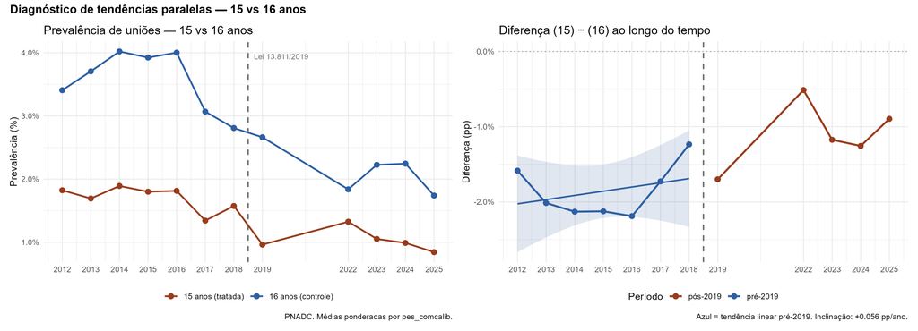

### Figura — Event Study

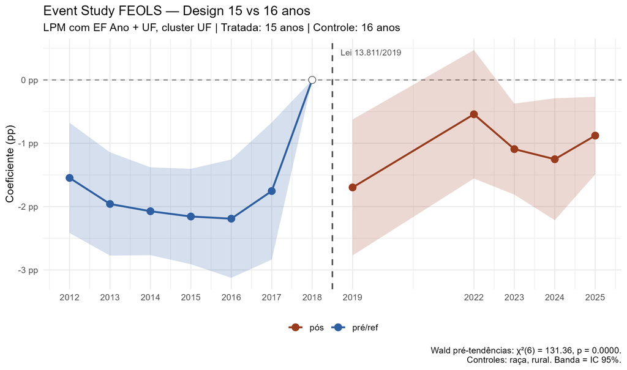

## Bloco 1b — DR-DiD: 15 vs 16

Estimamos o DR-DiD mesmo sabendo da violação estrutural — para mostrar explicitamente que o estimador duplamente robusto também não a resolve. O HonestDiD (Bloco 1c) confirma formalmente essa fragilidade.

**Como funciona o `att_gt()`:** para cada par (cohort $g$, período $t$), estima ATT$(g, t)$ via estimador DR. Com um único cohort ($G = 2019$), o event study é simplesmente ATT$(2019, t)$ normalizado em relação a 2018.

### Código

```r
dados_cs_1516 <- dados_1516 |>
  mutate(
    G      = if_else(D_15 == 1L, 2019, 0),  # double: did converte 0 → Inf internamente
    id_obs = row_number()
  )

cs_1516 <- att_gt(
  yname = "em_uniao", tname = "Ano", idname = "id_obs", gname = "G",
  data          = as.data.frame(dados_cs_1516),
  panel         = FALSE,            # RC: cortes transversais repetidos
  control_group = "nevertreated",   # G=0: 16 anos, nunca diretamente afetadas
  xformla       = ~ parda_preta + rural,
  weightsname   = "pes_comcalib",
  est_method    = "dr",             # doubly robust
  base_period   = "universal"       # ref = 2018 (G−1 = 2019−1)
)

att_es_1516 <- aggte(cs_1516, type = "dynamic", na.rm = TRUE)
att_ov_1516 <- aggte(cs_1516, type = "simple",  na.rm = TRUE)
```

### Event study por período

```r
if (!is.null(cs_1516)) {
  tab_event_study(att_es_1516) |>
    knitr::kable(
      caption = "DR-DiD event study — 15 vs 16. e = tempo relativo a 2019. Valores em pp.",
      align   = "rrrrrrr"
    )
}
```

DR-DiD event study — 15 vs 16. e = tempo relativo a 2019. Valores em pp.

| e | Ano | ATT (pp) | SE (pp) | IC inf | IC sup | Período |
| --- | --- | --- | --- | --- | --- | --- |
| -7 | 2012 | -0.257 | 0.602 | -1.436 | 0.922 | Pré |
| -6 | 2013 | -0.634 | 0.610 | -1.829 | 0.561 | Pré |
| -5 | 2014 | -0.764 | 0.631 | -2.001 | 0.474 | Pré |
| -4 | 2015 | -0.855 | 0.635 | -2.100 | 0.390 | Pré |
| -3 | 2016 | -0.891 | 0.631 | -2.129 | 0.346 | Pré |
| -2 | 2017 | -0.451 | 0.584 | -1.596 | 0.693 | Pré |
| -1 | 2018 | 0.000 | NA | NA | NA | Pré |
| 0 | 2019 | -0.479 | 0.561 | -1.579 | 0.620 | Pós |
| 3 | 2022 | 0.720 | 0.591 | -0.439 | 1.880 | Pós |
| 4 | 2023 | 0.108 | 0.655 | -1.177 | 1.392 | Pós |
| 5 | 2024 | 0.097 | 0.609 | -1.097 | 1.290 | Pós |
| 6 | 2025 | 0.318 | 0.547 | -0.754 | 1.391 | Pós |

### ATT agregado

```r
if (!is.na(ATT_CS_1516)) {
  tab_att("CS (2021) — 15 vs 16", ATT_CS_1516, SE_CS_1516, PVAL_CS_1516) |>
    knitr::kable(caption = "ATT geral pós-2019 (aggte type='simple').", align="lrrrrrr")
}
```

ATT geral pós-2019 (aggte type=‘simple’).

| Estimador | ATT (pp) | SE (pp) | p-valor | Sig | IC inf | IC sup |
| --- | --- | --- | --- | --- | --- | --- |
| CS (2021) — 15 vs 16 | 0.1527 | 0.4522 | 0.7355 |  | -0.734 | 1.039 |

### Figura

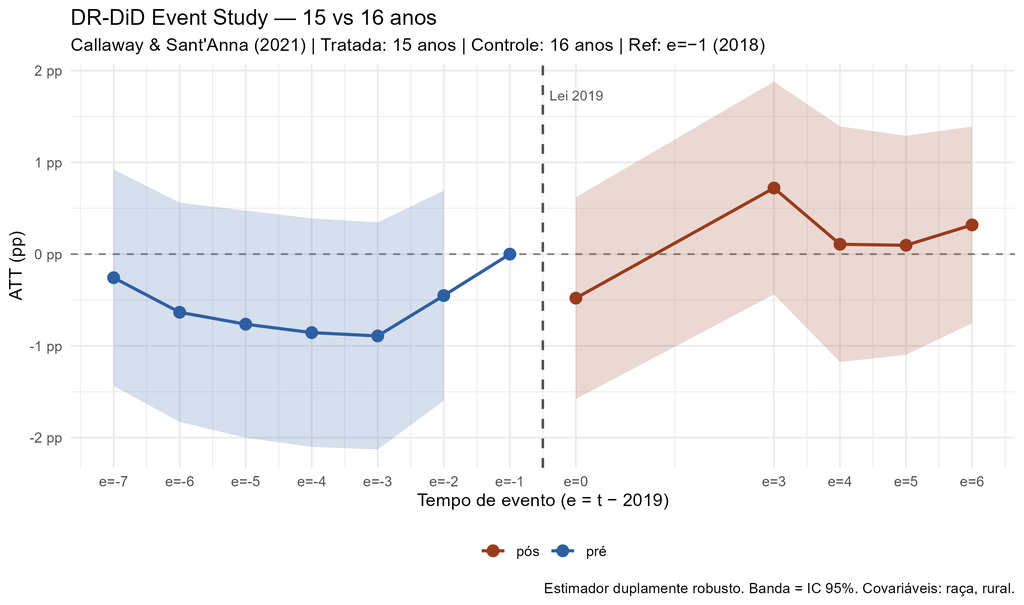

## Bloco 1c — HonestDiD: 15 vs 16

**Rambachan & Roth (2023):** em vez de assumir tendências paralelas exatas, o HonestDiD constrói ICs válidos se as violações pós-2019 forem limitadas:

- **ΔRM** (Magnitude Relativa): violações pós ≤ $\bar{M}$ × máxima violação pré. $\bar{M} = 0$ exige paralelas exatas; $\bar{M} = 1$ permite violações tão grandes quanto as pré-2019.
- **ΔSD** (Suavidade): tendência pré pode continuar no pós com desvio ≤ $M$ pp/período.

### Parâmetros usados

```r
if (!is.null(hd_1516)) {
  hd_inp_1516 <- extrair_honestdid_inputs(att_es_1516)
  cat(sprintf("Períodos:    %d pré + %d pós\n",
              hd_inp_1516$numPre, hd_inp_1516$numPost))
  cat(sprintf("M calibrado: %.5f (%.3f pp)  [máx. variação pré-2018]\n",
              hd_1516$M_cal, hd_1516$M_cal * 100))
  cat(sprintf("Mbarvec ΔRM: 0 a 2 (passo 0.25)\n"))
}
```

```
## Períodos:    6 pré + 5 pós
## M calibrado: 0.00440 (0.440 pp)  [máx. variação pré-2018]
## Mbarvec ΔRM: 0 a 2 (passo 0.25)
```

### Resultados ΔRM

```r
tab_honestdid(hd_1516$rm, "HonestDiD ΔRM — 15 vs 16. Valores em pp.")
```

HonestDiD ΔRM — 15 vs 16. Valores em pp.

| lb | ub | method | Delta | Mbar |
| --- | --- | --- | --- | --- |
| -1.561 | 0.618 | C-LF | DeltaRM | 0 |
| -1.696 | 0.753 | C-LF | DeltaRM | 25 |
| -1.921 | 0.955 | C-LF | DeltaRM | 50 |
| -2.213 | 1.247 | C-LF | DeltaRM | 75 |
| -2.595 | 1.651 | C-LF | DeltaRM | 100 |
| -3.021 | 2.056 | C-LF | DeltaRM | 125 |
| -3.448 | 2.482 | C-LF | DeltaRM | 150 |
| -3.898 | 2.932 | C-LF | DeltaRM | 175 |
| -4.324 | 3.381 | C-LF | DeltaRM | 200 |

### Resultados ΔSD

```r
tab_honestdid(hd_1516$sm, "HonestDiD ΔSD — 15 vs 16. Valores em pp.")
```

HonestDiD ΔSD — 15 vs 16. Valores em pp.

| lb | ub | method | Delta | M |
| --- | --- | --- | --- | --- |
| -2.505 | 0.640 | C-LF | DeltaSD | 0.000 |
| -2.633 | 0.786 | C-LF | DeltaSD | 0.165 |
| -2.787 | 0.913 | C-LF | DeltaSD | 0.330 |
| -2.920 | 1.067 | C-LF | DeltaSD | 0.495 |
| -3.080 | 1.201 | C-LF | DeltaSD | 0.660 |
| -3.219 | 1.363 | C-LF | DeltaSD | 0.825 |
| -3.361 | 1.503 | C-LF | DeltaSD | 0.990 |
| -3.506 | 1.648 | C-LF | DeltaSD | 1.155 |
| -3.678 | 1.795 | C-LF | DeltaSD | 1.320 |

### Figura ΔRM

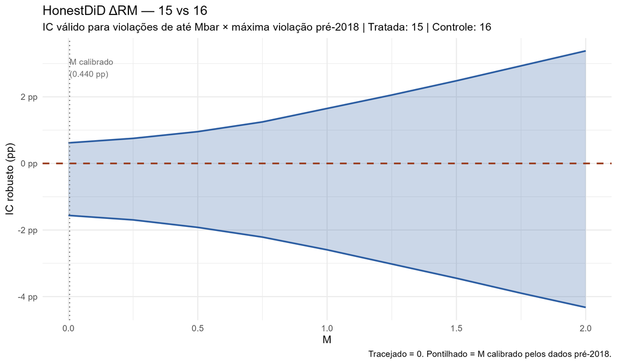

### Figura ΔSD

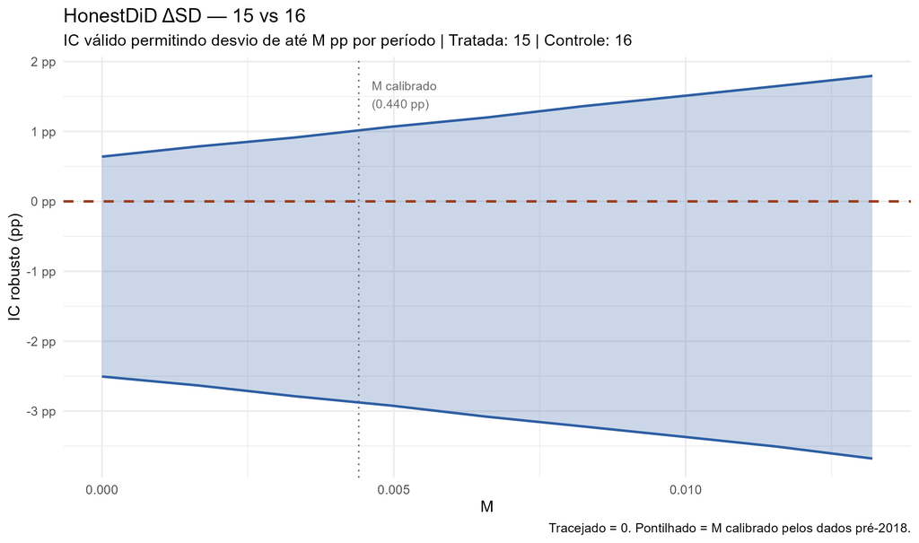

> **Conclusão:** IC inclui zero mesmo para $\bar{M} \to 0$, confirmando que a violação é estrutural.

## Bloco 2 — DR-DiD: 14–15 vs 16–17

Design principal. O controle (16–17 anos) não sofreu mudança normativa direta em 2019.

**Risco de contaminação:** meninas de 16 estavam exatamente no antigo limiar legal. Parte das que casariam aos 15 pode ter adiado para os 16 após a lei — o que afeta o controle. O Bloco 4 testa isso com controle mais distante.

### Código

```r
dados_cs_1617 <- didc_pnadc |>
  filter(idade %in% c(IDADES_TRAT, IDADES_CTRL1),
         Ano   %in% c(ANO_REF, ANOS_EVT)) |>
  mutate(D = as.integer(idade %in% IDADES_TRAT),
         G = if_else(D == 1L, 2019, 0), id_obs = row_number())

cs_1617 <- att_gt(
  yname="em_uniao", tname="Ano", idname="id_obs", gname="G",
  data=as.data.frame(dados_cs_1617), panel=FALSE,
  control_group="nevertreated", xformla=~parda_preta+rural,
  weightsname="pes_comcalib", est_method="dr", base_period="universal"
)
```

### Estatísticas descritivas

```r
cat(sprintf("N total:          %d\n", nrow(dados_cs_1617)))
```

```
## N total:          166938
```

```r
cat(sprintf("Tratadas (14-15): %d\n", sum(dados_cs_1617$D == 1)))
```

```
## Tratadas (14-15): 83047
```

```r
cat(sprintf("Controle (16-17): %d\n", sum(dados_cs_1617$D == 0)))
```

```
## Controle (16-17): 83891
```

### Event study por período

```r
if (!is.null(cs_1617)) {
  tab_event_study(att_es_1617) |>
    knitr::kable(
      caption = "DR-DiD event study — 14–15 vs 16–17. e = tempo relativo a 2019. Valores em pp.",
      align   = "rrrrrrr"
    )
}
```

DR-DiD event study — 14–15 vs 16–17. e = tempo relativo a 2019. Valores em pp.

| e | Ano | ATT (pp) | SE (pp) | IC inf | IC sup | Período |
| --- | --- | --- | --- | --- | --- | --- |
| -7 | 2012 | -1.319 | 0.495 | -2.289 | -0.350 | Pré |
| -6 | 2013 | -0.941 | 0.463 | -1.849 | -0.033 | Pré |
| -5 | 2014 | -0.621 | 0.470 | -1.542 | 0.300 | Pré |
| -4 | 2015 | -1.266 | 0.486 | -2.219 | -0.314 | Pré |
| -3 | 2016 | -0.786 | 0.471 | -1.709 | 0.137 | Pré |
| -2 | 2017 | -0.597 | 0.472 | -1.523 | 0.329 | Pré |
| -1 | 2018 | 0.000 | NA | NA | NA | Pré |
| 0 | 2019 | -0.435 | 0.483 | -1.381 | 0.511 | Pós |
| 3 | 2022 | 1.070 | 0.455 | 0.179 | 1.961 | Pós |
| 4 | 2023 | 0.547 | 0.499 | -0.431 | 1.524 | Pós |
| 5 | 2024 | 0.955 | 0.433 | 0.106 | 1.805 | Pós |
| 6 | 2025 | 0.956 | 0.441 | 0.091 | 1.822 | Pós |

### ATT agregado

```r
if (!is.na(ATT_CS_1617)) {
  tab_att("CS (2021) — 14-15 vs 16-17", ATT_CS_1617, SE_CS_1617, PVAL_CS_1617) |>
    knitr::kable(caption="ATT geral pós-2019 (aggte type='simple').", align="lrrrrrr")
}
```

ATT geral pós-2019 (aggte type=‘simple’).

| Estimador | ATT (pp) | SE (pp) | p-valor | Sig | IC inf | IC sup |
| --- | --- | --- | --- | --- | --- | --- |
| CS (2021) — 14-15 vs 16-17 | 0.6187 | 0.3482 | 0.0756 | * | -0.064 | 1.301 |

### Figura — Tendências

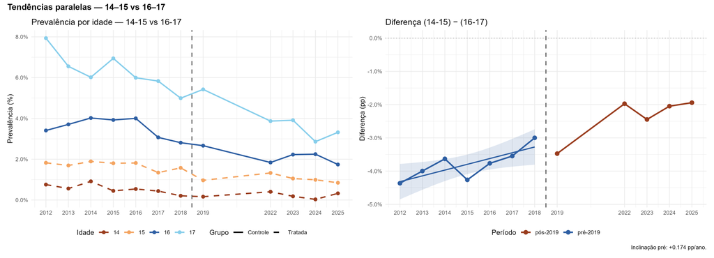

### Figura — Event Study

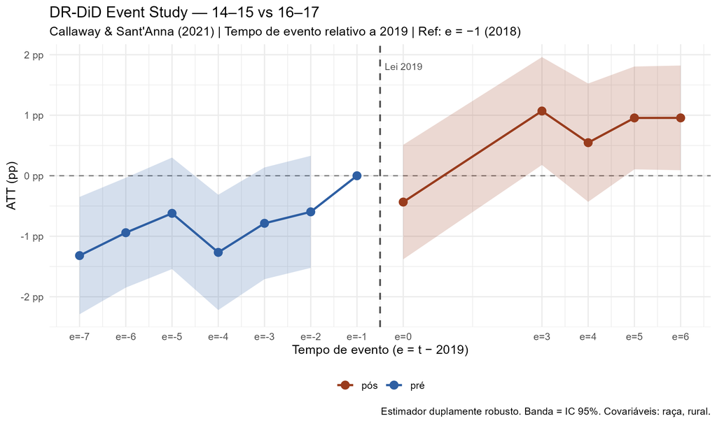

## Bloco 3 — HonestDiD: 14–15 vs 16–17

### Parâmetros

```r
if (!is.null(hd_1617)) {
  cat(sprintf("Períodos:    %d pré + %d pós\n",
              hd_inp_1617$numPre, hd_inp_1617$numPost))
  cat(sprintf("M calibrado: %.5f (%.3f pp)\n",
              hd_1617$M_cal, hd_1617$M_cal * 100))
}
```

```
## Períodos:    6 pré + 5 pós
## M calibrado: 0.00645 (0.645 pp)
```

### Resultados ΔRM

```r
tab_honestdid(hd_1617$rm, "HonestDiD ΔRM — 14–15 vs 16–17. lb/ub em pp.")
```

HonestDiD ΔRM — 14–15 vs 16–17. lb/ub em pp.

| lb | ub | method | Delta | Mbar |
| --- | --- | --- | --- | --- |
| -1.362 | 0.493 | C-LF | DeltaRM | 0 |
| -1.536 | 0.667 | C-LF | DeltaRM | 25 |
| -1.749 | 0.879 | C-LF | DeltaRM | 50 |
| -2.058 | 1.188 | C-LF | DeltaRM | 75 |
| -2.444 | 1.575 | C-LF | DeltaRM | 100 |
| -2.831 | 1.961 | C-LF | DeltaRM | 125 |
| -3.237 | 2.367 | C-LF | DeltaRM | 150 |
| -3.662 | 2.792 | C-LF | DeltaRM | 175 |
| -4.087 | 3.217 | C-LF | DeltaRM | 200 |

### Resultados ΔSD

```r
tab_honestdid(hd_1617$sm, "HonestDiD ΔSD — 14–15 vs 16–17. Valores em pp.")
```

HonestDiD ΔSD — 14–15 vs 16–17. Valores em pp.

| lb | ub | method | Delta | M |
| --- | --- | --- | --- | --- |
| -2.348 | 0.280 | C-LF | DeltaSD | 0.000 |
| -2.545 | 0.485 | C-LF | DeltaSD | 0.242 |
| -2.750 | 0.700 | C-LF | DeltaSD | 0.484 |
| -2.961 | 0.904 | C-LF | DeltaSD | 0.726 |
| -3.178 | 1.116 | C-LF | DeltaSD | 0.968 |
| -3.403 | 1.337 | C-LF | DeltaSD | 1.210 |
| -3.635 | 1.567 | C-LF | DeltaSD | 1.452 |
| -3.873 | 1.806 | C-LF | DeltaSD | 1.694 |
| -4.095 | 2.030 | C-LF | DeltaSD | 1.936 |

### Figura ΔRM

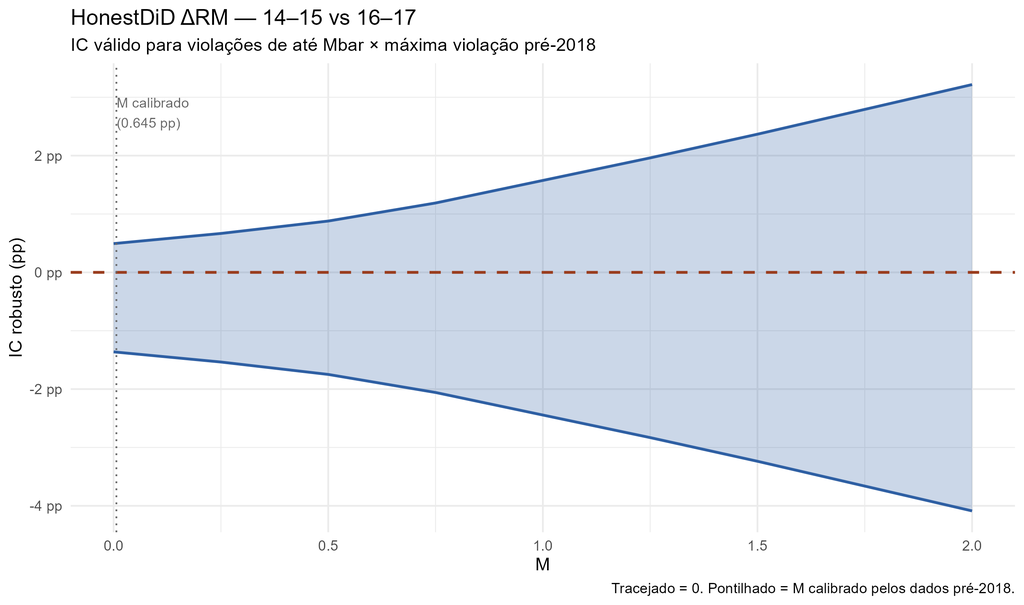

### Figura ΔSD

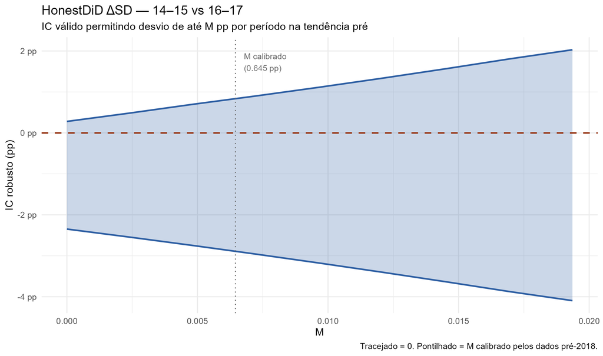

## Bloco 4 — DR-DiD: 14–15 vs 17–18 (robustez)

Controle alternativo mais distante do cutoff, menos suscetível à contaminação do limiar de 16 anos.

### Estatísticas descritivas

```r
cat(sprintf("N total:          %d\n", nrow(dados_cs_1718)))
```

```
## N total:          166648
```

```r
cat(sprintf("Tratadas (14-15): %d\n", sum(dados_cs_1718$D == 1)))
```

```
## Tratadas (14-15): 83047
```

```r
cat(sprintf("Controle (17-18): %d\n", sum(dados_cs_1718$D == 0)))
```

```
## Controle (17-18): 83601
```

### Event study por período

```r
if (!is.null(cs_1718)) {
  tab_event_study(att_es_1718) |>
    knitr::kable(
      caption = "DR-DiD event study — 14–15 vs 17–18. e = tempo relativo a 2019. Valores em pp.",
      align   = "rrrrrrr"
    )
}
```

DR-DiD event study — 14–15 vs 17–18. e = tempo relativo a 2019. Valores em pp.

| e | Ano | ATT (pp) | SE (pp) | IC inf | IC sup | Período |
| --- | --- | --- | --- | --- | --- | --- |
| -7 | 2012 | -2.561 | 0.642 | -3.819 | -1.303 | Pré |
| -6 | 2013 | -1.655 | 0.577 | -2.787 | -0.523 | Pré |
| -5 | 2014 | -0.250 | 0.578 | -1.383 | 0.882 | Pré |
| -4 | 2015 | -2.044 | 0.625 | -3.269 | -0.819 | Pré |
| -3 | 2016 | -1.134 | 0.602 | -2.314 | 0.046 | Pré |
| -2 | 2017 | -0.579 | 0.602 | -1.758 | 0.600 | Pré |
| -1 | 2018 | 0.000 | NA | NA | NA | Pré |
| 0 | 2019 | 0.984 | 0.584 | -0.160 | 2.128 | Pós |
| 3 | 2022 | 2.218 | 0.598 | 1.047 | 3.390 | Pós |
| 4 | 2023 | 2.139 | 0.584 | 0.995 | 3.284 | Pós |
| 5 | 2024 | 2.034 | 0.597 | 0.863 | 3.204 | Pós |
| 6 | 2025 | 2.063 | 0.566 | 0.955 | 3.171 | Pós |

### ATT agregado

```r
if (!is.na(ATT_CS_1718)) {
  tab_att("CS (2021) — 14-15 vs 17-18", ATT_CS_1718, SE_CS_1718, PVAL_CS_1718) |>
    knitr::kable(caption="ATT geral pós-2019.", align="lrrrrrr")
}
```

ATT geral pós-2019.

| Estimador | ATT (pp) | SE (pp) | p-valor | Sig | IC inf | IC sup |
| --- | --- | --- | --- | --- | --- | --- |
| CS (2021) — 14-15 vs 17-18 | 1.8877 | 0.4516 | 0 | *** | 1.003 | 2.773 |

### Tabela comparativa — todos os DiD

```r
dplyr::bind_rows(
  tab_att("TWFE — 14-15 vs 16-17 (benchmark)", att_twfe,    se_twfe,    pval_twfe),
  tab_att("CS (2021) — 14-15 vs 16-17",        ATT_CS_1617, SE_CS_1617, PVAL_CS_1617),
  tab_att("CS (2021) — 14-15 vs 17-18",        ATT_CS_1718, SE_CS_1718, PVAL_CS_1718)
) |>
  knitr::kable(
    caption = "Comparação entre estimadores DiD. *** p<0.01 ** p<0.05 * p<0.10. Valores em pp.",
    align   = "lrrrrrr"
  )
```

Comparação entre estimadores DiD. *** p<0.01 ** p<0.05 * p<0.10. Valores em pp.

| Estimador | ATT (pp) | SE (pp) | p-valor | Sig | IC inf | IC sup |
| --- | --- | --- | --- | --- | --- | --- |
| TWFE — 14-15 vs 16-17 (benchmark) | NA | NA | NA |  | NA | NA |
| CS (2021) — 14-15 vs 16-17 | 0.6187 | 0.3482 | 0.0756 | * | -0.064 | 1.301 |
| CS (2021) — 14-15 vs 17-18 | 1.8877 | 0.4516 | 0.0000 | *** | 1.003 | 2.773 |

### Figura — Tendências

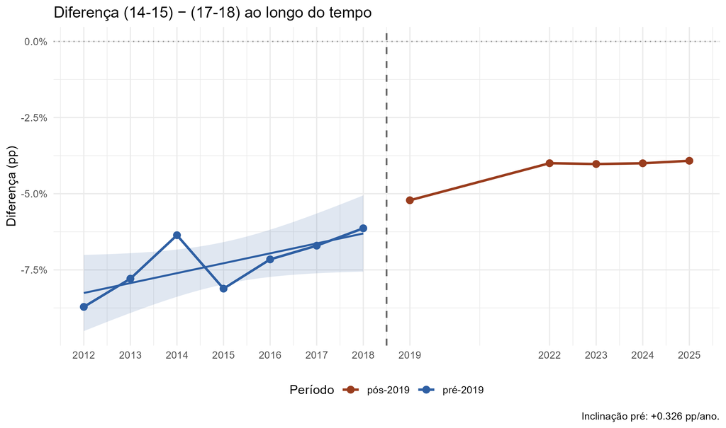

### Figura — Event Study

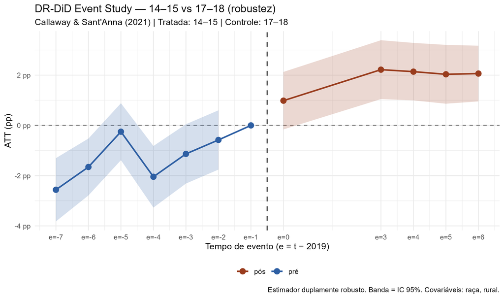

## Bloco 5 — HonestDiD: 14–15 vs 17–18 (robustez)

### Parâmetros

```r
if (!is.null(hd_1718)) {
  cat(sprintf("Períodos:    %d pré + %d pós\n",
              hd_inp_1718$numPre, hd_inp_1718$numPost))
  cat(sprintf("M calibrado: %.5f (%.3f pp)\n",
              hd_1718$M_cal, hd_1718$M_cal * 100))
}
```

```
## Períodos:    6 pré + 5 pós
## M calibrado: 0.01794 (1.794 pp)
```

### Resultados ΔRM

```r
tab_honestdid(hd_1718$rm, "HonestDiD ΔRM — 14–15 vs 17–18 (robustez). lb/ub em pp.")
```

HonestDiD ΔRM — 14–15 vs 17–18 (robustez). lb/ub em pp.

| lb | ub | method | Delta | Mbar |
| --- | --- | --- | --- | --- |
| -0.152 | 2.115 | C-LF | DeltaRM | 0 |
| -0.549 | 2.535 | C-LF | DeltaRM | 25 |
| -1.110 | 3.073 | C-LF | DeltaRM | 50 |
| -1.764 | 3.751 | C-LF | DeltaRM | 75 |
| -2.489 | 4.475 | C-LF | DeltaRM | 100 |
| -3.236 | 5.223 | C-LF | DeltaRM | 125 |
| -4.008 | 5.970 | C-LF | DeltaRM | 150 |
| -4.779 | 6.742 | C-LF | DeltaRM | 175 |
| -5.550 | 7.536 | C-LF | DeltaRM | 200 |

### Figura ΔRM

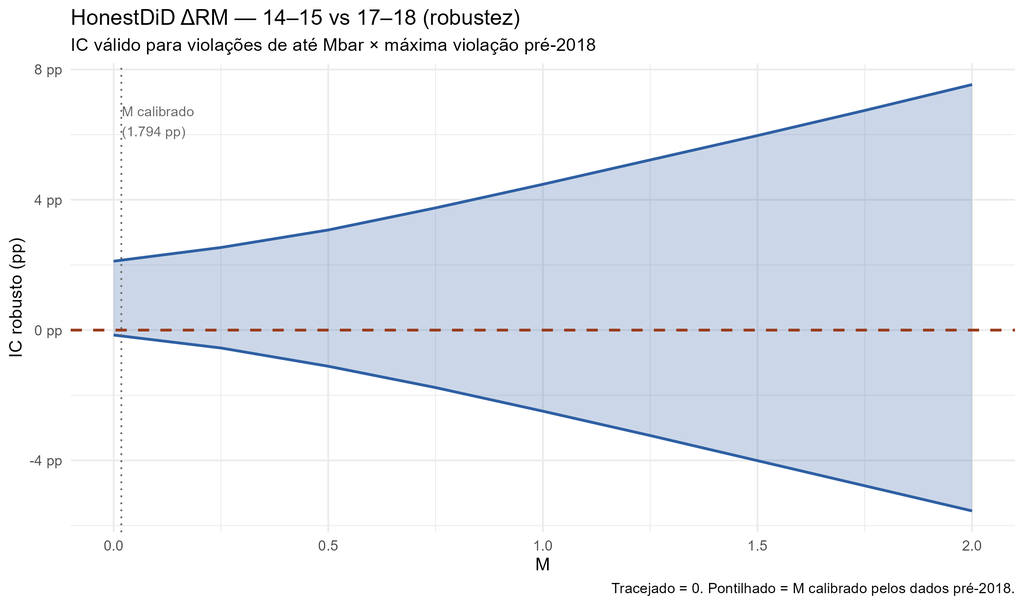

## Bloco 6 — DiDC: Estimador Principal

**Difference-in-Discontinuities (DiDC)** seguindo Pichetti et al. (2023).

$$\hat{\beta}_{\text{DiDC}} =
\widehat{RD}_{\text{pós}} - \widehat{RD}_{\text{pré}}$$

onde $\widehat{RD}$ é o salto na prevalência de uniões **no cutoff de 16 anos**, estimado por regressão local linear (`rdrobust`, kernel triangular, $p = 1$).

**Design invertido:** a running variable é $c = 16 - \text{idade}$, de modo que $c > 0$ identifica as meninas **abaixo de 16 anos** — o grupo diretamente afetado pela lei. Assim, $\hat{\beta} < 0$ indica que a lei **reduziu** uniões nesse grupo.

**Vantagem sobre o DiD:** não exige tendências paralelas entre grupos etários distintos — exige apenas continuidade local ao redor do cutoff de 16 anos.

Como funciona o `rdrobust()`: para o período pré (2012–2018) e pós (2019, 2022, 2023, 2024, 2025) separadamente, ajusta duas retas locais ponderadas pelo kernel triangular — uma para cada lado do cutoff — e extrai a diferença dos interceptos em $c = 0$.

### Código

```r
# ── Passo 1: running variable invertida ──────────────────────────────────────
# c > 0  →  abaixo de 16 anos (tratadas pela lei)
# c < 0  →  acima de 16 anos (controle)
dados_cont <- dados_cont |>
  mutate(c_inv = 16 - idade_cont)

# ── Passo 2: separar períodos ─────────────────────────────────────────────────
dat_pre <- dados_cont |> filter(Ano %in% 2012:2018)
dat_pos <- dados_cont |> filter(Ano %in% ANOS_POS)   # 2019, 2022–2025

# ── Passo 3: estimar RD em cada período via rdrobust ─────────────────────────
# rdrobust ajusta retas locais em cada lado do cutoff (c = 0)
# e retorna o salto entre os dois interceptos, com bias-correction.
rd_pre <- rdrobust(y = dat_pre$em_uniao, x = dat_pre$c_inv,
                   h = 1, p = 1, kernel = "triangular",
                   weights = dat_pre$pes_comcalib, masspoints = "adjust")

rd_pos <- rdrobust(y = dat_pos$em_uniao, x = dat_pos$c_inv,
                   h = 1, p = 1, kernel = "triangular",
                   weights = dat_pos$pes_comcalib, masspoints = "adjust")

# ── Passo 4: DiDC = RD_pós − RD_pré ─────────────────────────────────────────
beta_didc <- rd_pos$coef[2] - rd_pre$coef[2]           # bias-corrected
se_didc   <- sqrt(rd_pre$se[3]^2 + rd_pos$se[3]^2)     # método delta
```

### Tabela de robustez

Como o estimador RD depende do bandwidth $h$, testamos $h \in \{0.50,\ 0.75,\ 1.00,\ 1.50,\ 2.00,\ 2.50,\ 3.00\}$ anos. Um resultado robusto apresenta **coeficiente estável** e **SE decrescente** com $h$.

```r
if (exists("bw_tab") && !is.null(bw_tab) && nrow(bw_tab) > 0) {
  bw_tab |>
    dplyr::mutate(
      Sig = dplyr::case_when(
        is.na(pval)   ~ "",
        pval < 0.01   ~ "***",
        pval < 0.05   ~ "**",
        pval < 0.10   ~ "*",
        TRUE          ~ ""
      ),
      Principal = ifelse(h == 1.00, "←", "")
    ) |>
    dplyr::transmute(
      `h (anos)`    = h,
      `N pré`       = N_pre,
      `N pós`       = N_pos,
      `RD pré (pp)` = round(RD_pre, 3),
      `RD pós (pp)` = round(RD_pos, 3),
      `β_DiDC (pp)` = round(beta,   3),
      `SE (pp)`     = round(se,     3),
      `Sig`         = Sig,
      ` `           = Principal
    ) |>
    knitr::kable(
      caption = paste(
        "Robustez do β_DiDC por bandwidth (design invertido Pichetti).",
        "RD = E[Y | idade < 16] − E[Y | idade ≥ 16].",
        "β < 0 indica redução de uniões abaixo de 16 anos.",
        "*** p<0.01  ** p<0.05  * p<0.10"
      ),
      align = "rrrrrrrll"
    )
}
```

Robustez do β_DiDC por bandwidth (design invertido Pichetti). RD = E[Y | idade < 16] − E[Y | idade ≥ 16]. β < 0 indica redução de uniões abaixo de 16 anos. *** p<0.01 ** p<0.05 * p<0.10

| h (anos) | N pré | N pós | RD pré (pp) | RD pós (pp) | β_DiDC (pp) | SE (pp) | Sig |  |
| --- | --- | --- | --- | --- | --- | --- | --- | --- |
| 0.50 | 22048 | 12423 | 1.273 | 0.882 | -0.390 | 1.158 |  |  |
| 0.75 | 32929 | 18502 | 0.464 | 0.467 | 0.003 | 0.943 |  |  |
| 1.00 | 44180 | 24990 | 0.336 | 0.432 | 0.096 | 0.830 |  | ← |
| 1.50 | 66061 | 37575 | 0.620 | 0.153 | -0.466 | 0.695 |  |  |
| 2.00 | 87898 | 50003 | 0.393 | 0.098 | -0.295 | 0.606 |  |  |
| 2.50 | 109170 | 62415 | 0.294 | 0.066 | -0.228 | 0.550 |  |  |
| 3.00 | 127550 | 73200 | 0.228 | -0.039 | -0.267 | 0.508 |  |  |

### Resultado principal

```r
if (exists("didc_rd") && !is.na(didc_rd)) {
  sig <- dplyr::case_when(
    pval_didc_rd < 0.01 ~ "***",
    pval_didc_rd < 0.05 ~ "**",
    pval_didc_rd < 0.10 ~ "*",
    TRUE                ~ "(não significativo)"
  )
  tibble::tibble(
    Estimador  = "DiDC rdrobust — design invertido (h = 1.00)",
    `β (pp)`   = round(didc_rd * 100, 3),
    `SE (pp)`  = round(se_didc_rd * 100, 3),
    `p-valor`  = round(pval_didc_rd, 4),
    Sig        = sig,
    `IC inf`   = round((didc_rd - 1.96 * se_didc_rd) * 100, 3),
    `IC sup`   = round((didc_rd + 1.96 * se_didc_rd) * 100, 3)
  ) |>
    knitr::kable(
      caption = paste(
        "β_DiDC = RD_pós − RD_pré no cutoff de 16 anos.",
        "rdrobust, p=1, kernel triangular, masspoints='adjust'.",
        "SE via método delta (√(SE_pré² + SE_pós²))."
      )
    )
}
```

β_DiDC = RD_pós − RD_pré no cutoff de 16 anos. rdrobust, p=1, kernel triangular, masspoints=‘adjust’. SE via método delta (√(SE_pré² + SE_pós²)).

| Estimador | β (pp) | SE (pp) | p-valor | Sig | IC inf | IC sup |
| --- | --- | --- | --- | --- | --- | --- |
| DiDC rdrobust — design invertido (h = 1.00) | 0.096 | 0.83 | 0.908 | (não significativo) | -1.531 | 1.722 |

### teste de bandwidth ótimo

```r
# Bandwidth ótimo escolhido automaticamente pelo rdrobust (critério MSE)
rd_pre_opt <- rdrobust(
  y          = dat_pre$em_uniao,
  x          = dat_pre$c_inv,
  p          = 1,
  kernel     = "triangular",
  weights    = dat_pre$pes_comcalib,
  masspoints = "adjust"
)

rd_pos_opt <- rdrobust(
  y          = dat_pos$em_uniao,
  x          = dat_pos$c_inv,
  p          = 1,
  kernel     = "triangular",
  weights    = dat_pos$pes_comcalib,
  masspoints = "adjust"
)

# Bandwidth selecionado (para reportar)
h_opt_pre <- rd_pre_opt$bws[1, 1]
h_opt_pos <- rd_pos_opt$bws[1, 1]

# β_DiDC com bandwidth ótimo
beta_didc_opt <- rd_pos_opt$coef[2] - rd_pre_opt$coef[2]
se_didc_opt   <- sqrt(rd_pre_opt$se[3]^2 + rd_pos_opt$se[3]^2)
pval_didc_opt <- 2 * pnorm(-abs(beta_didc_opt / se_didc_opt))



sig <- dplyr::case_when(
  pval_didc_opt < 0.01 ~ "***",
  pval_didc_opt < 0.05 ~ "**",
  pval_didc_opt < 0.10 ~ "*",
  TRUE                 ~ "(não significativo)"
)

tibble::tibble(
  Estimador = sprintf("DiDC rdrobust (h_pré=%.2f, h_pós=%.2f)", h_opt_pre, h_opt_pos),
  `β (pp)`  = round(beta_didc_opt * 100, 3),
  `SE (pp)` = round(se_didc_opt   * 100, 3),
  `p-valor` = round(pval_didc_opt, 4),
  Sig       = sig,
  `IC inf`  = round((beta_didc_opt - 1.96 * se_didc_opt) * 100, 3),
  `IC sup`  = round((beta_didc_opt + 1.96 * se_didc_opt) * 100, 3)
) |>
  knitr::kable(
    caption = paste(
      "β_DiDC = RD_pós − RD_pré no cutoff de 16 anos.",
      "Bandwidth selecionado pelo critério MSE (Calonico, Cattaneo & Titiunik, 2014).",
      "SE via método delta."
    )
  )
```

β_DiDC = RD_pós − RD_pré no cutoff de 16 anos. Bandwidth selecionado pelo critério MSE (Calonico, Cattaneo & Titiunik, 2014). SE via método delta.

| Estimador | β (pp) | SE (pp) | p-valor | Sig | IC inf | IC sup |
| --- | --- | --- | --- | --- | --- | --- |
| DiDC rdrobust (h_pré=0.93, h_pós=1.12) | -0.513 | 0.688 | 0.456 | (não significativo) | -1.861 | 0.835 |

### Figura — Event Study DiDC

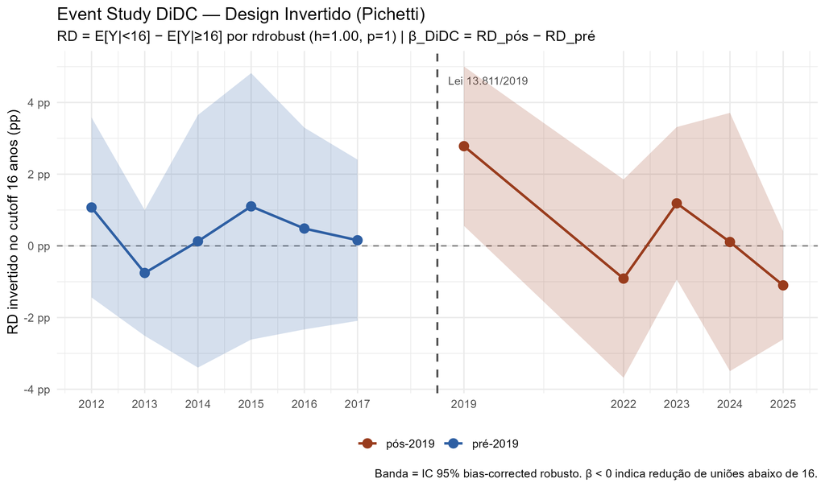

### Figura — Descontinuidade visual

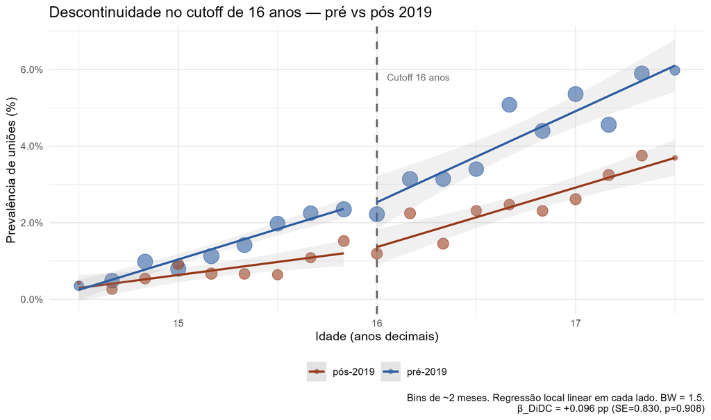

### Figura — Event Study (h ótimo)

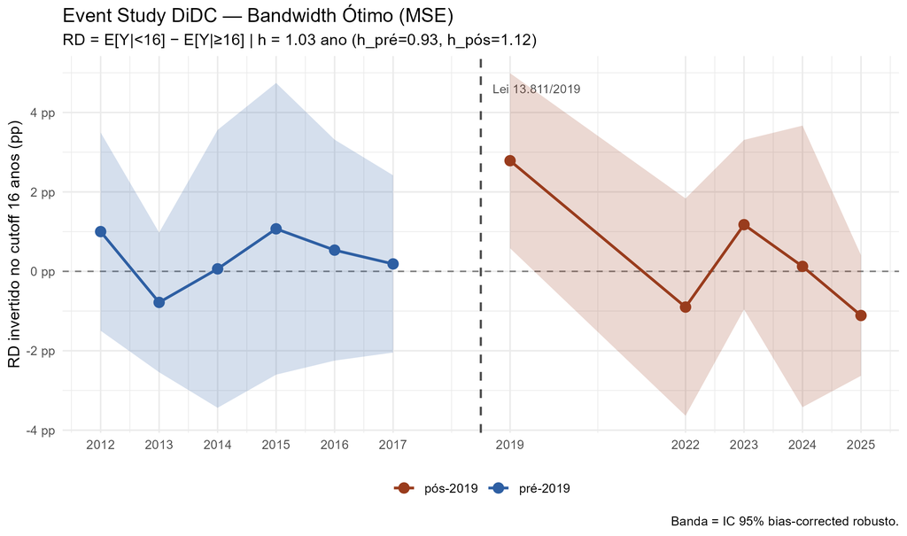

### Figura — Descontinuidade visual (h ótimo)

Prevalência de uniões por bin de ~2 meses de idade, dentro do **bandwidth ótimo** selecionado pelo critério MSE. Cada ponto é um bin; o tamanho é proporcional ao número de observações. As retas são ajustes lineares locais separados para abaixo e acima do cutoff de 16 anos.

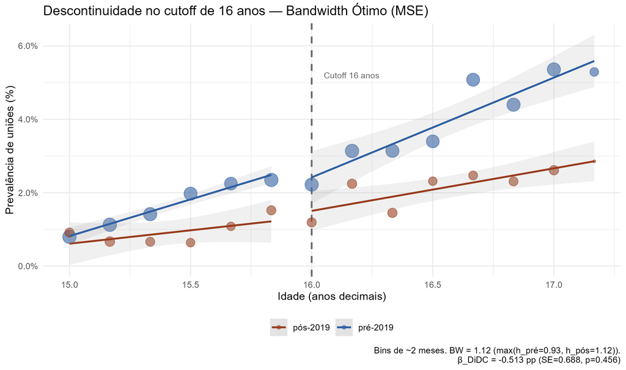

## Bloco 7 — DR-DiD com Idade Contínua

Mesmo estimador de Callaway & Sant’Anna (2021), mas com duas diferenças em relação aos Blocos 2–4:

1. **Tratamento definido por `idade_cont < 16`** (precisão mensal) em vez de grupo etário inteiro — uma menina de 15 anos e 11 meses é corretamente classificada como tratada; uma de 16 anos e 0 meses como controle
2. **`idade_cont` entra como covariável contínua** no propensity score e na regressão do outcome — o DR-DiD condiciona na idade exata, não apenas no grupo anual

### Código

```r
# Tratamento definido pela idade contínua (meses)
dados_cs_cont_A <- didc_pnadc |>
  filter(idade %in% c(IDADES_TRAT, IDADES_CTRL1), Ano %in% c(ANO_REF, ANOS_EVT),
         !is.na(idade_cont)) |>
  mutate(D_cont = as.integer(idade_cont < 16),
         G      = if_else(D_cont == 1L, 2019, 0),
         id_obs = row_number())

# Fórmula com idade contínua como covariável
COVAR_FORMULA_CONT <- ~ idade_cont + parda_preta + rural + factor(UF)

cs_cont_A <- att_gt(
  yname="em_uniao", tname="Ano", idname="id_obs", gname="G",
  data=as.data.frame(dados_cs_cont_A), panel=FALSE,
  control_group="nevertreated", xformla=COVAR_FORMULA_CONT,
  weightsname="pes_comcalib", est_method="dr", base_period="universal"
)
```

### Estatísticas descritivas

```r
if (exists("dados_cs_cont_A") && !is.null(dados_cs_cont_A)) {
  tibble::tibble(
    Design      = c("A: <16 vs 16–17", "B: <16 vs 17–18"),
    `N total`   = c(nrow(dados_cs_cont_A), nrow(dados_cs_cont_B)),
    `Tratadas`  = c(sum(dados_cs_cont_A$D_cont==1), sum(dados_cs_cont_B$D_cont==1)),
    `Controle`  = c(sum(dados_cs_cont_A$D_cont==0), sum(dados_cs_cont_B$D_cont==0))
  ) |> knitr::kable(caption="Amostras por design (idade contínua).", align="lrrr")
}
```

Amostras por design (idade contínua).

| Design | N total | Tratadas | Controle |
| --- | --- | --- | --- |
| A: <16 vs 16–17 | 149714 | 74697 | 75017 |
| B: <16 vs 17–18 | 149112 | 69786 | 79326 |

### Event study — Design A (<16 vs 16–17)

```r
if (!is.null(cs_cont_A)) {
  tab_event_study(att_es_cont_A) |>
    knitr::kable(
      caption="DR-DiD cont — <16 vs 16–17. e = tempo relativo a 2019. Valores em pp.",
      align="rrrrrrr"
    )
}
```

DR-DiD cont — <16 vs 16–17. e = tempo relativo a 2019. Valores em pp.

| e | Ano | ATT (pp) | SE (pp) | IC inf | IC sup | Período |
| --- | --- | --- | --- | --- | --- | --- |
| -7 | 2012 | 3.331 | 1.377 | 0.633 | 6.030 | Pré |
| -6 | 2013 | 2.356 | 1.480 | -0.545 | 5.257 | Pré |
| -5 | 2014 | 0.757 | 2.242 | -3.637 | 5.151 | Pré |
| -4 | 2015 | 1.104 | 1.854 | -2.529 | 4.738 | Pré |
| -3 | 2016 | -0.132 | 1.715 | -3.493 | 3.229 | Pré |
| -2 | 2017 | 1.615 | 1.581 | -1.484 | 4.714 | Pré |
| -1 | 2018 | 0.000 | NA | NA | NA | Pré |
| 0 | 2019 | 2.006 | 1.477 | -0.890 | 4.902 | Pós |
| 3 | 2022 | -0.701 | 1.702 | -4.036 | 2.635 | Pós |
| 4 | 2023 | 0.505 | 1.313 | -2.069 | 3.079 | Pós |
| 5 | 2024 | -0.035 | 1.505 | -2.985 | 2.915 | Pós |
| 6 | 2025 | 0.593 | 1.204 | -1.767 | 2.954 | Pós |

### ATT agregado — Design A

```r
if (!is.na(ATT_CS_CONT_A)) {
  tab_att("CS cont — <16 vs 16–17", ATT_CS_CONT_A, SE_CS_CONT_A, PVAL_CS_CONT_A) |>
    knitr::kable(caption="ATT geral pós-2019 (aggte type='simple').", align="lrrrrrr")
}
```

ATT geral pós-2019 (aggte type=‘simple’).

| Estimador | ATT (pp) | SE (pp) | p-valor | Sig | IC inf | IC sup |
| --- | --- | --- | --- | --- | --- | --- |
| CS cont — <16 vs 16–17 | 0.4739 | 1.188 | 0.69 |  | -1.855 | 2.802 |

### Event study — Design B (<16 vs 17–18)

```r
if (!is.null(cs_cont_B)) {
  tab_event_study(att_es_cont_B) |>
    knitr::kable(
      caption="DR-DiD cont — <16 vs 17–18. e = tempo relativo a 2019. Valores em pp.",
      align="rrrrrrr"
    )
}
```

DR-DiD cont — <16 vs 17–18. e = tempo relativo a 2019. Valores em pp.

| e | Ano | ATT (pp) | SE (pp) | IC inf | IC sup | Período |
| --- | --- | --- | --- | --- | --- | --- |
| -7 | 2012 | 1.871 | 1.605 | -1.274 | 5.016 | Pré |
| -6 | 2013 | 1.967 | 1.634 | -1.235 | 5.169 | Pré |
| -5 | 2014 | -1.582 | 3.594 | -8.625 | 5.462 | Pré |
| -4 | 2015 | 2.284 | 1.496 | -0.649 | 5.217 | Pré |
| -3 | 2016 | 1.156 | 2.366 | -3.481 | 5.792 | Pré |
| -2 | 2017 | -0.030 | 1.784 | -3.528 | 3.467 | Pré |
| -1 | 2018 | 0.000 | NA | NA | NA | Pré |
| 0 | 2019 | 0.401 | 1.554 | -2.645 | 3.446 | Pós |
| 3 | 2022 | -2.337 | 2.557 | -7.349 | 2.675 | Pós |
| 4 | 2023 | -0.899 | 1.416 | -3.675 | 1.876 | Pós |
| 5 | 2024 | 0.201 | 1.834 | -3.394 | 3.797 | Pós |
| 6 | 2025 | 0.677 | 1.458 | -2.181 | 3.534 | Pós |

### ATT agregado — Design B

```r
if (!is.na(ATT_CS_CONT_B)) {
  tab_att("CS cont — <16 vs 17–18", ATT_CS_CONT_B, SE_CS_CONT_B, PVAL_CS_CONT_B) |>
    knitr::kable(caption="ATT geral pós-2019 (aggte type='simple').", align="lrrrrrr")
}
```

ATT geral pós-2019 (aggte type=‘simple’).

| Estimador | ATT (pp) | SE (pp) | p-valor | Sig | IC inf | IC sup |
| --- | --- | --- | --- | --- | --- | --- |
| CS cont — <16 vs 17–18 | -0.3916 | 1.3742 | 0.7756 |  | -3.085 | 2.302 |

### Comparação com modelos de grupo etário inteiro

```r
dplyr::bind_rows(
  tab_att("CS — 14-15 vs 16-17 (grupo inteiro)",  ATT_CS_1617,   SE_CS_1617,   PVAL_CS_1617),
  tab_att("CS — 14-15 vs 17-18 (grupo inteiro)",  ATT_CS_1718,   SE_CS_1718,   PVAL_CS_1718),
  tab_att("CS cont — <16 vs 16-17 (mês preciso)", ATT_CS_CONT_A, SE_CS_CONT_A, PVAL_CS_CONT_A),
  tab_att("CS cont — <16 vs 17-18 (mês preciso)", ATT_CS_CONT_B, SE_CS_CONT_B, PVAL_CS_CONT_B)
) |>
  knitr::kable(
    caption=paste("Grupo inteiro: tratamento por idade inteira (14-15).",
                  "Mês preciso: tratamento por idade_cont < 16.",
                  "Covariável idade_cont contínua no modelo de mês preciso."),
    align="lrrrrrr"
  )
```

Grupo inteiro: tratamento por idade inteira (14-15). Mês preciso: tratamento por idade_cont < 16. Covariável idade_cont contínua no modelo de mês preciso.

| Estimador | ATT (pp) | SE (pp) | p-valor | Sig | IC inf | IC sup |
| --- | --- | --- | --- | --- | --- | --- |
| CS — 14-15 vs 16-17 (grupo inteiro) | 0.6187 | 0.3482 | 0.0756 | * | -0.064 | 1.301 |
| CS — 14-15 vs 17-18 (grupo inteiro) | 1.8877 | 0.4516 | 0.0000 | *** | 1.003 | 2.773 |
| CS cont — <16 vs 16-17 (mês preciso) | 0.4739 | 1.1880 | 0.6900 |  | -1.855 | 2.802 |
| CS cont — <16 vs 17-18 (mês preciso) | -0.3916 | 1.3742 | 0.7756 |  | -3.085 | 2.302 |

## Bloco 8 — DR-DiD com Bandwidth Local

Mesmo estimador duplamente robusto (Callaway & Sant’Anna 2021), mas restringindo a amostra a meninas próximas do cutoff de 16 anos. A lógica é análoga ao RD: quanto mais estreito o bandwidth, mais comparáveis são tratadas e controle — ao custo de menor N.

- **Tratadas:** `idade_cont < 16` (abaixo de 16 em precisão mensal)
- **Controle:** `idade_cont ≥ 16` (acima de 16, consentimento parental continua permitido)
- **Covariável:** `idade_cont` contínua no propensity score e outcome regression
- **Bandwidths:** ±1.0, ±0.75 e ±0.50 anos

### Código

```r
df <- dados_cont |>
  filter(abs(idade_c_cont) <= BW, !is.na(idade_cont)) |>
  mutate(
    D_cont = as.integer(idade_c_cont < 0),   # tratada: abaixo de 16
    G      = if_else(D_cont == 1L, 2019, 0),
    id_obs = row_number()
  )

cs_bw <- att_gt(
  yname="em_uniao", tname="Ano", idname="id_obs", gname="G",
  data=as.data.frame(df), panel=FALSE, control_group="nevertreated",
  xformla = ~ idade_cont + parda_preta + rural + uf_fct,
  weightsname="pes_comcalib", est_method="dr", base_period="universal"
)
```

### Estatísticas por bandwidth

```r
if (!is.null(cs_bw_resultados)) {
  purrr::map_dfr(cs_bw_resultados, function(res) {
    if (is.null(res)) return(NULL)
    tibble::tibble(
      `Bandwidth`      = sprintf("±%.2f anos (~±%d meses)", res$bw, round(res$bw*12)),
      `N total`        = nrow(res$df),
      `Tratadas (<16)` = sum(res$df$D_cont == 1),
      `Controle (≥16)` = sum(res$df$D_cont == 0)
    )
  }) |> knitr::kable(caption = "Tamanho amostral por bandwidth.", align = "lrrr")
}
```

Tamanho amostral por bandwidth.

| Bandwidth | N total | Tratadas (<16) | Controle (≥16) |
| --- | --- | --- | --- |
| ±1.00 anos (~±12 meses) | 69170 | 34684 | 34486 |
| ±0.75 anos (~±9 meses) | 51431 | 25651 | 25780 |
| ±0.50 anos (~±6 meses) | 34471 | 17033 | 17438 |

### ATT por bandwidth

```r
if (!is.null(cs_bw_resultados)) {
  purrr::map_dfr(cs_bw_resultados, function(res) {
    if (is.null(res) || is.na(res$att)) return(NULL)
    tab_att(
      sprintf("DR-DiD BW ±%.2f anos (~±%d meses)", res$bw, round(res$bw*12)),
      res$att, res$se, res$pval
    )
  }) |>
    knitr::kable(
      caption = paste(
        "DR-DiD por bandwidth. Tratadas: idade_cont < 16. Controle: idade_cont ≥ 16.",
        "Covariáveis: idade_cont + raça + rural + UF.",
        "*** p<0.01 ** p<0.05 * p<0.10. Valores em pp."
      ),
      align = "lrrrrrr"
    )
}
```

DR-DiD por bandwidth. Tratadas: idade_cont < 16. Controle: idade_cont ≥ 16. Covariáveis: idade_cont + raça + rural + UF. *** p<0.01 ** p<0.05 * p<0.10. Valores em pp.

| Estimador | ATT (pp) | SE (pp) | p-valor | Sig | IC inf | IC sup |
| --- | --- | --- | --- | --- | --- | --- |
| DR-DiD BW ±1.00 anos (~±12 meses) | -0.7121 | 0.9517 | 0.4543 |  | -2.577 | 1.153 |
| DR-DiD BW ±0.75 anos (~±9 meses) | 0.5504 | 0.9264 | 0.5525 |  | -1.265 | 2.366 |
| DR-DiD BW ±0.50 anos (~±6 meses) | -1.1179 | 1.1149 | 0.3160 |  | -3.303 | 1.067 |

### Event study — ±1.00 ano

```r
res <- cs_bw_resultados[["bw1"]]
if (!is.null(res) && !is.null(res$att_es)) {
  tab_event_study(res$att_es) |>
    knitr::kable(caption = "DR-DiD BW ±1.00 ano — event study por período. Valores em pp.",
                 align = "rrrrrrr")
}
```

DR-DiD BW ±1.00 ano — event study por período. Valores em pp.

| e | Ano | ATT (pp) | SE (pp) | IC inf | IC sup | Período |
| --- | --- | --- | --- | --- | --- | --- |
| -7 | 2012 | 3.044 | 1.309 | 0.479 | 5.610 | Pré |
| -6 | 2013 | 1.582 | 1.300 | -0.965 | 4.129 | Pré |
| -5 | 2014 | 0.245 | 2.433 | -4.523 | 5.013 | Pré |
| -4 | 2015 | -0.283 | 1.890 | -3.987 | 3.421 | Pré |
| -3 | 2016 | -0.708 | 1.711 | -4.063 | 2.646 | Pré |
| -2 | 2017 | 0.000 | NA | NA | NA | Pré |
| 0 | 2019 | 1.158 | 1.317 | -1.424 | 3.739 | Pós |
| 3 | 2022 | -2.029 | 1.780 | -5.517 | 1.459 | Pós |
| 4 | 2023 | -0.527 | 1.146 | -2.773 | 1.719 | Pós |
| 5 | 2024 | -1.192 | 1.256 | -3.654 | 1.269 | Pós |
| 6 | 2025 | -0.969 | 1.033 | -2.993 | 1.055 | Pós |

### Event study — ±0.75 ano

```r
res <- cs_bw_resultados[["bw0.75"]]
if (!is.null(res) && !is.null(res$att_es)) {
  tab_event_study(res$att_es) |>
    knitr::kable(caption = "DR-DiD BW ±0.75 ano — event study por período. Valores em pp.",
                 align = "rrrrrrr")
}
```

DR-DiD BW ±0.75 ano — event study por período. Valores em pp.

| e | Ano | ATT (pp) | SE (pp) | IC inf | IC sup | Período |
| --- | --- | --- | --- | --- | --- | --- |
| -7 | 2012 | 3.226 | 1.364 | 0.552 | 5.901 | Pré |
| -6 | 2013 | 2.750 | 1.422 | -0.038 | 5.537 | Pré |
| -5 | 2014 | 0.280 | 2.494 | -4.608 | 5.167 | Pré |
| -4 | 2015 | 0.814 | 1.951 | -3.011 | 4.639 | Pré |
| -3 | 2016 | 1.945 | 2.049 | -2.070 | 5.961 | Pré |
| -2 | 2017 | 0.000 | NA | NA | NA | Pré |
| 0 | 2019 | 2.081 | 1.199 | -0.269 | 4.431 | Pós |
| 3 | 2022 | -0.930 | 1.879 | -4.612 | 2.752 | Pós |
| 4 | 2023 | 1.646 | 1.324 | -0.948 | 4.240 | Pós |
| 5 | 2024 | -0.389 | 1.258 | -2.856 | 2.077 | Pós |
| 6 | 2025 | 0.344 | 1.167 | -1.944 | 2.633 | Pós |

### Event study — ±0.50 ano

```r
res <- cs_bw_resultados[["bw0.5"]]
if (!is.null(res) && !is.null(res$att_es)) {
  tab_event_study(res$att_es) |>
    knitr::kable(caption = "DR-DiD BW ±0.50 ano — event study por período. Valores em pp.",
                 align = "rrrrrrr")
}
```

DR-DiD BW ±0.50 ano — event study por período. Valores em pp.

| e | Ano | ATT (pp) | SE (pp) | IC inf | IC sup | Período |
| --- | --- | --- | --- | --- | --- | --- |
| -7 | 2012 | 0.854 | 1.509 | -2.103 | 3.811 | Pré |
| -6 | 2013 | 0.406 | 1.462 | -2.459 | 3.270 | Pré |
| -5 | 2014 | -2.031 | 2.855 | -7.626 | 3.565 | Pré |
| -4 | 2015 | -1.948 | 2.221 | -6.301 | 2.405 | Pré |
| -3 | 2016 | -2.323 | 2.006 | -6.255 | 1.608 | Pré |
| -2 | 2017 | 0.000 | NA | NA | NA | Pré |
| 0 | 2019 | 0.117 | 1.414 | -2.654 | 2.888 | Pós |
| 3 | 2022 | -2.373 | 2.154 | -6.596 | 1.849 | Pós |
| 4 | 2023 | 0.087 | 1.428 | -2.712 | 2.886 | Pós |
| 5 | 2024 | -1.713 | 1.540 | -4.731 | 1.305 | Pós |
| 6 | 2025 | -1.708 | 1.248 | -4.154 | 0.738 | Pós |

## Sumário Final

### Tabela consolidada

```r
linhas <- list(
  list("CS (2021) — 15 vs 16 (diagnóstico)", ATT_CS_1516, SE_CS_1516, PVAL_CS_1516),
  list("TWFE — 14-15 vs 16-17 (benchmark)",  att_twfe,    se_twfe,    pval_twfe),
  list("CS (2021) — 14-15 vs 16-17",         ATT_CS_1617, SE_CS_1617, PVAL_CS_1617),
  list("CS (2021) — 14-15 vs 17-18",         ATT_CS_1718, SE_CS_1718, PVAL_CS_1718)
)
if (exists("didc_rd") && !is.na(didc_rd))
  linhas <- c(linhas, list(
    list("**DiDC rdrobust — design invertido, h=1.00 (PRINCIPAL)**", didc_rd, se_didc_rd, pval_didc_rd)
  ))

purrr::map_dfr(linhas, ~tab_att(.x[[1]], .x[[2]], .x[[3]], .x[[4]])) |>
  knitr::kable(
    caption = paste(
      "Sumário de todos os estimadores. Valores em pontos percentuais (pp).",
      "*** p<0.01  ** p<0.05  * p<0.10.",
      "CS = Callaway & Sant'Anna (2021), doubly robust, RC."
    ),
    align = "lrrrrrr"
  )
```

Sumário de todos os estimadores. Valores em pontos percentuais (pp). *** p<0.01 ** p<0.05 * p<0.10. CS = Callaway & Sant’Anna (2021), doubly robust, RC.

| Estimador | ATT (pp) | SE (pp) | p-valor | Sig | IC inf | IC sup |
| --- | --- | --- | --- | --- | --- | --- |
| CS (2021) — 15 vs 16 (diagnóstico) | 0.1527 | 0.4522 | 0.7355 |  | -0.734 | 1.039 |
| TWFE — 14-15 vs 16-17 (benchmark) | NA | NA | NA |  | NA | NA |
| CS (2021) — 14-15 vs 16-17 | 0.6187 | 0.3482 | 0.0756 | * | -0.064 | 1.301 |
| CS (2021) — 14-15 vs 17-18 | 1.8877 | 0.4516 | 0.0000 | *** | 1.003 | 2.773 |
| **DiDC rdrobust — design invertido, h=1.00 (PRINCIPAL)** | 0.0959 | 0.8298 | 0.9080 |  | -1.531 | 1.722 |

### HonestDiD — robustez

```r
tibble::tribble(
  ~Design,                    ~`M calibrado (pp)`, ~`M_max robusto (ΔRM)`, ~`Frágil?`,
  "15 vs 16 (diagnóstico)",
    if (!is.null(hd_1516)) round(hd_1516$M_cal*100,4) else NA_real_,
    NA_real_, "Sim (estrutural)",
  "14-15 vs 16-17",
    if (!is.null(hd_1617)) round(hd_1617$M_cal*100,4) else NA_real_,
    NA_real_, "Ver tabela Bloco 3",
  "14-15 vs 17-18",
    if (!is.null(hd_1718)) round(hd_1718$M_cal*100,4) else NA_real_,
    NA_real_, "Ver tabela Bloco 5"
) |>
  knitr::kable(
    caption="Sumário HonestDiD. M calibrado = máxima variação observada nos coeficientes pré-2018.",
    align="lrrl"
  )
```

Sumário HonestDiD. M calibrado = máxima variação observada nos coeficientes pré-2018.

| Design | M calibrado (pp) | M_max robusto (ΔRM) | Frágil? |
| --- | --- | --- | --- |
| 15 vs 16 (diagnóstico) | 0.4400 | NA | Sim (estrutural) |
| 14-15 vs 16-17 | 0.6453 | NA | Ver tabela Bloco 3 |
| 14-15 vs 17-18 | 1.7938 | NA | Ver tabela Bloco 5 |

## Referências

- Callaway & Sant’Anna (2021). *Journal of Econometrics*, 225(2), 200–230.
- Rambachan & Roth (2023). *Review of Economic Studies*, 90(5), 2555–2591.
- Sant’Anna & Zhao (2020). *Journal of Econometrics*, 219(1), 101–122.
- Calonico, Cattaneo & Titiunik (2014). *Econometrica*, 82(6), 2295–2326.